# The importance of Eager Execution in TF2

## 郭耀仁 Yao-Jen Kuo

## Agenda

- TL; DR
- Getting Started with Eager Execution
- Miscellaneous

## TL; DR

> Eager execution is an imperative programming environment in TF and has become the default mode in TF2. Comparing to its declarative interface, eager execution is more flexible, convenient, and debuggable. Meanwhile, TF2 also preserves the advantage of declarative interface, say building computational graphs. Users now can program eagerly doing quick experiment and switch to graph seamlessly when necessary, thus achieves a great balance between eager and graph.

## Getting Started with Eager Execution

## On October 31, 2017, Google Brain introduced eager execution in TF 1.7.0

> Eager mode is moving out of contrib, try `tf.enable_eager_execution()`

Source: https://github.com/tensorflow/tensorflow/blob/master/RELEASE.md#release-170

## Every operation must be done within session previously

```python
import tensorflow as tf

ff = tf.constant([5, 5], shape=(1, 2))
ss = tf.constant([6, 6], shape=(2, 1))
ffss = tf.matmul(ff, ss)
# printing out ffss is useless
print(ffss)
```

## We have to create a session to execute the operation

```python
with tf.Session() as sess:
    ans = sess.run(ffss)
print(ans)
```

## This is so called "building a computational graph" which was the default way to use TF

```python
print("Is TesorFlow {} executing eagerly? {}".format(tf.__version__, tf.executing_eagerly()))
```

## We could switch to eager mode manually after TF1.7.0

```python
# reset all runtimes before executing this cell
import tensorflow as tf

tf.enable_eager_execution() # run before any other TF codes
print("Is TesorFlow {} executing eagerly? {}".format(tf.__version__, tf.executing_eagerly()))
```

## Eager execution in one sentence

> Using TensorFlow like NumPy.

```python
ff = tf.constant([5, 5], shape=(1, 2))
ss = tf.constant([6, 6], shape=(2, 1))
ffss = tf.matmul(ff, ss)
print(ffss.numpy())
print(type(ffss.numpy()))
```

## Eager execution is now the default mode in TF2

```python
# reset all runtimes before executing this cell
!pip install tensorflow==2.0.0
```

```python
import tensorflow as tf

print("Is TesorFlow {} executing eagerly? {}".format(tf.__version__, tf.executing_eagerly()))
```

## What if we want to use computational graph in TF2?

Use `tf.function()` instead.

```python
ff = tf.constant([5, 5], shape=(1, 2))
ss = tf.constant([6, 6], shape=(2, 1))
@tf.function
def matmul(a, b):
    return tf.matmul(a, b)
matmul(ff, ss)
```

## Something different in Eager Execution

- Printing out tensors is convenient and meaningful
- Placeholders are not supported
- Iterating is a **LOT** is easier
- Using `tf.GradientTape()` to compute gradients

## Printing out tensors is convenient and meaningful

```python
my_tensor = tf.constant([5566])
print(my_tensor)
print(my_tensor.numpy())
```

## Placeholders are not supported

```python
my_ph = tf.placeholder(tf.int32, shape=(1))
```

## Iterating data declaratively

```python
fav_numbers = tf.constant([5, 5, 6, 6])
dataset = tf.data.Dataset.from_tensor_slices(fav_numbers)
iterator = dataset.make_initializable_iterator()
el = iterator.get_next()
with tf.Session() as sess:
    sess.run(iterator.initializer)
    for i in range(fav_numbers.shape[0]):
        print(sess.run(el))
```

## Iterating data eagerly

```python
fav_numbers = tf.constant([5, 5, 6, 6])
for fav_num in fav_numbers:
    print(fav_num.numpy())
```

## Using `tf.GradientTape()` to compute gradients

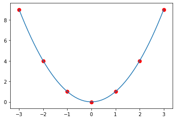

```python
get_plot()
```

```python
x = tf.Variable([-3., -2., -1., 0., 1., 2., 3.])
with tf.GradientTape() as tape:
    y = x**2

dydx = tape.gradient(y, x)
print(dydx.numpy())
```

## How linear regression is programmed in graph and in eager, respectively.

## Linear regression with `tf.Session()` in TF1

```python
# reset all runtimes before executing this cell
import tensorflow as tf

print("Is TesorFlow {} executing eagerly? {}".format(tf.__version__, tf.executing_eagerly()))
```

```python
# placeholders
X = tf.placeholder(tf.float32)
y = tf.placeholder(tf.float32)
# variables
W = tf.Variable(tf.random_normal((2, 1)))
# prediction
y_pred = tf.matmul(X, W)
# loss
loss = tf.reduce_mean(tf.pow(tf.subtract(y, y_pred), 2))
# optimizer
optimizer = tf.train.AdamOptimizer(learning_rate).minimize(loss)
```

```python
import numpy as np
from sklearn.preprocessing import PolynomialFeatures

# generate some data for y = 5x + 6
X_train = np.arange(30).reshape(-1, 1)
y_train = 5*X_train + 6
poly = PolynomialFeatures(1)
X_train = poly.fit_transform(X_train)
learning_rate = 0.001
epochs = 20000
# training
with tf.Session() as sess:
    sess.run(tf.global_variables_initializer()) # Initialize all variable tensors
    for i in range(epochs):
        training_data = {
            X: X_train,
            y: y_train
        }
        _, _loss = sess.run([optimizer, loss], feed_dict=training_data)
        if i % 2000 == 0:
            print("epoch: {}, loss: {}".format(i, _loss))
    W_final = sess.run(W)
print(W_final)
```

## Linear regression with eager execution in TF2

```python
# reset all runtimes before executing this cell
!pip install tensorflow==2.0.0
```

```python
import tensorflow as tf

print("Is TesorFlow {} executing eagerly? {}".format(tf.__version__, tf.executing_eagerly()))
```

```python
# model
class Linear(tf.keras.Model):
    def __init__(self):
        super(Linear, self).__init__()
        self.W = tf.Variable(tf.random.normal((2, 1), dtype='float32'), name='weights')
    def call(self, X):
        return tf.matmul(X, self.W)
# the loss function to be optimized
def loss(model, X, y):
    y_pred = model(X)
    return tf.reduce_mean(tf.pow(tf.subtract(y, y_pred), 2))
def grad(model, X, y):
    with tf.GradientTape() as tape:
        loss_value = loss(model, X, y)
    return tape.gradient(loss_value, [model.W])
```

```python
import numpy as np
from sklearn.preprocessing import PolynomialFeatures
import time

X_train = np.arange(30, dtype='float32').reshape(-1, 1)
y_train = 5*X_train + 6
poly = PolynomialFeatures(1)
X_train = poly.fit_transform(X_train)
epochs = 20000
model = Linear()
optimizer = tf.keras.optimizers.Adam(learning_rate=0.001)
t0 = time.time()
# training
for i in range(epochs):
    grads = grad(model, X_train, y_train)
    optimizer.apply_gradients(zip(grads, [model.W]))
    if i % 2000 == 0:
        print("epoch: {}, loss: {}".format(i, loss(model, X_train, y_train)))
t1 = time.time() - t0
print(model.W.numpy())
print("Time per epoch: {:.3f} s".format(t1/epochs))
```

## Make it fast in TF2 with `tf.function()`

```python
@tf.function
def grad(model, X, y):
    with tf.GradientTape() as tape:
        loss_value = loss(model, X, y)
    return tape.gradient(loss_value, [model.W])
```

```python
X_train = np.arange(30, dtype='float32').reshape(-1, 1)
y_train = 5*X_train + 6
poly = PolynomialFeatures(1)
X_train = poly.fit_transform(X_train)
epochs = 20000
model = Linear()
optimizer = tf.keras.optimizers.Adam(learning_rate=0.001)
t0 = time.time()
for i in range(epochs):
    grads = grad(model, X_train, y_train)
    optimizer.apply_gradients(zip(grads, [model.W]))
    if i % 2000 == 0:
        print("epoch: {}, loss: {}".format(i, loss(model, X_train, y_train)))
t1 = time.time() - t0
print(model.W.numpy())
print("Time per epoch: {:.3f} s".format(t1/epochs))
```

## Key takeaways

- Eager execution makes programming TF2 more flexible, readable, composable, intuitive, and debuggable
- With eager execution, we can learn TF2 more like other modern imperative deep learning frameworks like PyTorch and Gluon...etc.
- TF2 preserves the advantage of computational graph via `tf.function()`

## References

- [TensorFlow 2.0 + Keras Overview for Deep Learning Researchers](https://colab.research.google.com/drive/1UCJt8EYjlzCs1H1d1X0iDGYJsHKwu-NO)
- [Eager Execution: An imperative, define-by-run interface to TensorFlow](https://ai.googleblog.com/2017/10/eager-execution-imperative-define-by.html)
- [TensorFlow.org](https://www.tensorflow.org/)

## Miscellaneous

## TFUG Taipei is sponsored by Google Taiwan

[figure not shown]

## Let us know if...

- any topic you are interest in
- any speaker you want us to invite

https://forms.gle/VBDA72X1dNWbeLgN9